# Analisis financiero de las empresas del S&P500

En el presente informe se toma en cuenta el indice S&P500.Este índice se basa en la capitalización bursátil de 500 grandes empresas que poseen acciones que cotizan en las bolsas NYSE o NASDAQ, y captura aproximadamente el 80% de toda la capitalización de mercado. Se realiza un análisis sobre los distintas empresas a lo largo del tiempo para comprender mejor el mercado, y poder tomar decisiones en base a nuestras recomendaciones

### Se importan las librerías a utilizar

```python
import pandas as pd
import requests as r
import yfinance as yf
import seaborn as sns
from matplotlib import pyplot as plt
import datetime as dt
import numpy as np
from pypfopt.efficient_frontier import EfficientFrontier
from pypfopt import risk_models
from pypfopt import expected_returns
from pypfopt.expected_returns import mean_historical_return
sns.set()
```

### Se obtiene la lista de los S&P500 de Wikipedia https://en.wikipedia.org/wiki/List_of_S%26P_500_companies

```python
url = 'https://en.wikipedia.org/wiki/List_of_S%26P_500_companies'
pagina= r.get(url).content
lista_datos = pd.read_html(pagina)
type(lista_datos)
datos_wiki=lista_datos[0]
```

```python
datos_wiki.head(10)
```

|  | Symbol | Security | SEC filings | GICS Sector | GICS Sub-Industry | Headquarters Location | Date first added | CIK | Founded |
| --- | --- | --- | --- | --- | --- | --- | --- | --- | --- |
| 0 | MMM | 3M | reports | Industrials | Industrial Conglomerates | Saint Paul, Minnesota | 1976-08-09 | 66740 | 1902 |
| 1 | AOS | A. O. Smith | reports | Industrials | Building Products | Milwaukee, Wisconsin | 2017-07-26 | 91142 | 1916 |
| 2 | ABT | Abbott | reports | Health Care | Health Care Equipment | North Chicago, Illinois | 1964-03-31 | 1800 | 1888 |
| 3 | ABBV | AbbVie | reports | Health Care | Pharmaceuticals | North Chicago, Illinois | 2012-12-31 | 1551152 | 2013 (1888) |
| 4 | ABMD | Abiomed | reports | Health Care | Health Care Equipment | Danvers, Massachusetts | 2018-05-31 | 815094 | 1981 |
| 5 | ACN | Accenture | reports | Information Technology | IT Consulting & Other Services | Dublin, Ireland | 2011-07-06 | 1467373 | 1989 |
| 6 | ATVI | Activision Blizzard | reports | Communication Services | Interactive Home Entertainment | Santa Monica, California | 2015-08-31 | 718877 | 2008 |
| 7 | ADM | ADM | reports | Consumer Staples | Agricultural Products | Chicago, Illinois | 1981-07-29 | 7084 | 1902 |
| 8 | ADBE | Adobe Inc. | reports | Information Technology | Application Software | San Jose, California | 1997-05-05 | 796343 | 1982 |
| 9 | ADP | ADP | reports | Information Technology | Data Processing & Outsourced Services | Roseland, New Jersey | 1981-03-31 | 8670 | 1949 |

```python
df_simbolos=datos_wiki.iloc[:,[0,1,3,4]]
```

Se conservan los datos de las columnas relevantes para este informe

```python
print(df_simbolos)
```

```
    Symbol              Security             GICS Sector  \
0      MMM                    3M             Industrials
1      AOS           A. O. Smith             Industrials
2      ABT                Abbott             Health Care
3     ABBV                AbbVie             Health Care
4     ABMD               Abiomed             Health Care
..     ...                   ...                     ...
498    YUM           Yum! Brands  Consumer Discretionary
499   ZBRA    Zebra Technologies  Information Technology
500    ZBH         Zimmer Biomet             Health Care
501   ZION  Zions Bancorporation              Financials
502    ZTS                Zoetis             Health Care

                      GICS Sub-Industry
0              Industrial Conglomerates
1                     Building Products
2                 Health Care Equipment
3                       Pharmaceuticals
4                 Health Care Equipment
..                                  ...
498                         Restaurants
499  Electronic Equipment & Instruments
500               Health Care Equipment
501                      Regional Banks
502                     Pharmaceuticals

[503 rows x 4 columns]
```

```python
#df_simbolos['Symbol']=df_simbolos['Symbol'].replace('.','-')
df_simbolos['Symbol'] = df_simbolos['Symbol'].str.replace('.','-')      # Se reemplaza el '.' por '-' en la columna Symbol
```

```python
df_simbolos.head(10)
```

|  | Symbol | Security | GICS Sector | GICS Sub-Industry |
| --- | --- | --- | --- | --- |
| 0 | MMM | 3M | Industrials | Industrial Conglomerates |
| 1 | AOS | A. O. Smith | Industrials | Building Products |
| 2 | ABT | Abbott | Health Care | Health Care Equipment |
| 3 | ABBV | AbbVie | Health Care | Pharmaceuticals |
| 4 | ABMD | Abiomed | Health Care | Health Care Equipment |
| 5 | ACN | Accenture | Information Technology | IT Consulting & Other Services |
| 6 | ATVI | Activision Blizzard | Communication Services | Interactive Home Entertainment |
| 7 | ADM | ADM | Consumer Staples | Agricultural Products |
| 8 | ADBE | Adobe Inc. | Information Technology | Application Software |
| 9 | ADP | ADP | Information Technology | Data Processing & Outsourced Services |

# Se obtiene la lista de simbolos que se va a analizar

```python
#Se obtiene la lista de simbolos que se va a analizar
simbolos= df_simbolos['Symbol'].tolist()
```

```python
#Se descarga los datos de la API yahoo Finance usanado la libreria yfinance
df_data = yf.download(simbolos,start='2000-01-01',end='2020-12-31',group_by="ticker", threads=3)
df_data
```

```
[*********************100%***********************]  503 of 503 completed

2 Failed downloads:
- OGN: Data doesn't exist for startDate = 946702800, endDate = 1609390800
- CEG: Data doesn't exist for startDate = 946702800, endDate = 1609390800
```

| Date | OGN Open | OGN High | OGN Low | OGN Close | OGN Adj Close | OGN Volume | CFG Open | CFG High | CFG Low | CFG Close | ... | INCY Low | INCY Close | INCY Adj Close | INCY Volume | JBHT Open | JBHT High | JBHT Low | JBHT Close | JBHT Adj Close | JBHT Volume |
| --- | --- | --- | --- | --- | --- | --- | --- | --- | --- | --- | --- | --- | --- | --- | --- | --- | --- | --- | --- | --- | --- |
| 2014-09-24 | NaN | NaN | NaN | NaN | NaN | NaN | 21.500000 | 23.219999 | 21.350000 | 23.080000 | ... | 47.560001 | 49.330002 | 49.330002 | 734200.0 | 73.129997 | 73.129997 | 72.370003 | 72.750000 | 67.667778 | 707100.0 |
| 2014-09-25 | NaN | NaN | NaN | NaN | NaN | NaN | 22.559999 | 23.410000 | 22.450001 | 23.049999 | ... | 48.130001 | 48.660000 | 48.660000 | 885700.0 | 72.489998 | 73.150002 | 71.730003 | 72.849998 | 67.760796 | 1180200.0 |
| 2014-09-26 | NaN | NaN | NaN | NaN | NaN | NaN | 23.180000 | 23.370001 | 22.910000 | 23.250000 | ... | 48.400002 | 49.700001 | 49.700001 | 689600.0 | 73.070000 | 74.430000 | 72.900002 | 74.209999 | 69.025818 | 1050000.0 |
| 2014-09-29 | NaN | NaN | NaN | NaN | NaN | NaN | 23.139999 | 23.450001 | 22.910000 | 23.230000 | ... | 48.770000 | 50.520000 | 50.520000 | 847100.0 | 73.570000 | 74.099998 | 73.029999 | 74.000000 | 68.830444 | 622300.0 |
| 2014-09-30 | NaN | NaN | NaN | NaN | NaN | NaN | 23.110001 | 23.570000 | 23.049999 | 23.420000 | ... | 49.020000 | 49.049999 | 49.049999 | 995000.0 | 73.900002 | 74.279999 | 73.279999 | 74.050003 | 68.876968 | 857400.0 |
| ... | ... | ... | ... | ... | ... | ... | ... | ... | ... | ... | ... | ... | ... | ... | ... | ... | ... | ... | ... | ... | ... |
| 2014-09-19 | NaN | NaN | NaN | NaN | NaN | NaN | NaN | NaN | NaN | NaN | ... | 48.380001 | 49.320000 | 49.320000 | 1290400.0 | 74.209999 | 74.919998 | 74.160004 | 74.419998 | 69.221107 | 961000.0 |
| 2014-09-22 | NaN | NaN | NaN | NaN | NaN | NaN | NaN | NaN | NaN | NaN | ... | 46.730000 | 47.410000 | 47.410000 | 1040000.0 | 74.199997 | 74.379997 | 73.589996 | 73.629997 | 68.486305 | 431800.0 |
| 2014-09-23 | NaN | NaN | NaN | NaN | NaN | NaN | NaN | NaN | NaN | NaN | ... | 46.779999 | 47.470001 | 47.470001 | 993300.0 | 73.379997 | 73.680000 | 72.879997 | 72.930000 | 67.835197 | 564100.0 |
| 2020-12-31 | NaN | NaN | NaN | NaN | NaN | NaN | NaN | NaN | NaN | NaN | ... | NaN | NaN | NaN | NaN | NaN | NaN | NaN | NaN | NaN | NaN |
| 2001-09-12 | NaN | NaN | NaN | NaN | NaN | NaN | NaN | NaN | NaN | NaN | ... | NaN | NaN | NaN | NaN | NaN | NaN | NaN | NaN | NaN | NaN |

5285 rows × 3018 columns

Se construye un dataframe por cada activo en el cual se calcularan los indicadores necesarios. Luego cada dataframe por activo sera almacenado en una lista para posteriomente concatenarlos en un solo DataFrame Global

```python
df_data.columns
tickers=df_data.columns.get_level_values(0)
tickers=tickers.unique()
list_tickers=[]
for i in tickers:
    df_ticker=df_data.loc[:,i]
    df_ticker.reset_index(inplace=True)
    df_ticker=df_ticker.sort_values('Date')
    df_ticker=df_ticker.assign(Ticker=i)
    #Se calcula el Retorno GAP y se agrega esa columna
    df_ticker= df_ticker.assign(GAP_Return=lambda x: np.log(x['Open']/x['Close'].shift(1)).fillna(0))
    #Se calcula el Retorno Intradiario y se agrega esa columna
    df_ticker= df_ticker.assign(Intradaily_Return=lambda x: np.log(x['Close']/x['Open']).fillna(0))
    #Se calcula la variacion y se agrega esa columna
    df_ticker=df_ticker.assign(Variation= lambda x: x['Adj Close'].pct_change())
    #Se calcula la volatibilidad y se agrega esa columna
    df_ticker= df_ticker.assign(Volatility= lambda x: x['Variation'].rolling(250).std()*100*(250)**0.5 )
    list_tickers.append(df_ticker)

df_global=pd.concat(list_tickers)

df_global=df_global.assign(WeekDay=lambda x:x['Date'].dt.strftime('%A'))    #para conocer el dia de la semana
df_global=df_global.assign(Year_Month=lambda x:x['Date'].dt.strftime('%Y-%m'))      #para conocer el año y mes correspondiente
```

```python
df_global
```

|  | Date | Open | High | Low | Close | Adj Close | Volume | Ticker | GAP_Return | Intradaily_Return | Variation | Volatility | WeekDay | Year_Month |
| --- | --- | --- | --- | --- | --- | --- | --- | --- | --- | --- | --- | --- | --- | --- |
| 1579 | 2000-01-03 | NaN | NaN | NaN | NaN | NaN | NaN | OGN | 0.000000 | 0.000000 | NaN | NaN | Monday | 2000-01 |
| 1580 | 2000-01-04 | NaN | NaN | NaN | NaN | NaN | NaN | OGN | 0.000000 | 0.000000 | NaN | NaN | Tuesday | 2000-01 |
| 1581 | 2000-01-05 | NaN | NaN | NaN | NaN | NaN | NaN | OGN | 0.000000 | 0.000000 | NaN | NaN | Wednesday | 2000-01 |
| 1582 | 2000-01-06 | NaN | NaN | NaN | NaN | NaN | NaN | OGN | 0.000000 | 0.000000 | NaN | NaN | Thursday | 2000-01 |
| 1583 | 2000-01-07 | NaN | NaN | NaN | NaN | NaN | NaN | OGN | 0.000000 | 0.000000 | NaN | NaN | Friday | 2000-01 |
| ... | ... | ... | ... | ... | ... | ... | ... | ... | ... | ... | ... | ... | ... | ... |
| 1575 | 2020-12-24 | 138.110001 | 138.649994 | 136.720001 | 137.419998 | 135.851578 | 245300.0 | JBHT | -0.002387 | -0.005009 | -0.007368 | 41.121954 | Thursday | 2020-12 |
| 1576 | 2020-12-28 | 138.759995 | 139.119995 | 136.429993 | 136.740005 | 135.179367 | 493100.0 | JBHT | 0.009704 | -0.014664 | -0.004948 | 41.126244 | Monday | 2020-12 |
| 1577 | 2020-12-29 | 137.500000 | 138.270004 | 135.649994 | 136.100006 | 134.546661 | 491100.0 | JBHT | 0.005543 | -0.010234 | -0.004680 | 41.126668 | Tuesday | 2020-12 |
| 1578 | 2020-12-30 | 135.910004 | 136.779999 | 134.949997 | 135.440002 | 133.894196 | 395000.0 | JBHT | -0.001397 | -0.003464 | -0.004849 | 41.127576 | Wednesday | 2020-12 |
| 5283 | 2020-12-31 | NaN | NaN | NaN | NaN | NaN | NaN | JBHT | 0.000000 | 0.000000 | 0.000000 | 41.086614 | Thursday | 2020-12 |

2658355 rows × 14 columns

```python
df_global=df_global.assign(Year=lambda x:x['Date'].dt.strftime('%Y'))
```

```python
#Se verifica que todos los REtornos GAPS inicien en cero
verificar_inicio_cero=df_global.loc[df_global.Date=='2000-01-03','GAP_Return'].sum()
verificar_inicio_cero
```

```
0.0
```

# Análisis del mejor día para invertir usando el rendimiento gap.

Se elabora un dataframe con las columnas WeekDay y GAP_Return

```python
df_retorno_gaps= pd.DataFrame()

df_retorno_gaps=df_global[['WeekDay','GAP_Return']]
df_retorno_gaps
```

|  | WeekDay | GAP_Return |
| --- | --- | --- |
| 1579 | Monday | 0.000000 |
| 1580 | Tuesday | 0.000000 |
| 1581 | Wednesday | 0.000000 |
| 1582 | Thursday | 0.000000 |
| 1583 | Friday | 0.000000 |
| ... | ... | ... |
| 1575 | Thursday | -0.002387 |
| 1576 | Monday | 0.009704 |
| 1577 | Tuesday | 0.005543 |
| 1578 | Wednesday | -0.001397 |
| 5283 | Thursday | 0.000000 |

2658355 rows × 2 columns

Se calcula el Retorno Gap acumulado por dia

```python
df_Retorno_Gaps = df_global[['WeekDay','Ticker','GAP_Return']].groupby([df_global['WeekDay'],df_global['Ticker']]).sum()
df_Retorno_Gaps.reset_index(inplace=True)
df_Retorno_Gaps
```

|  | WeekDay | Ticker | GAP_Return |
| --- | --- | --- | --- |
| 0 | Friday | A | -0.360434 |
| 1 | Friday | AAL | 0.505713 |
| 2 | Friday | AAP | 0.391958 |
| 3 | Friday | AAPL | -0.547687 |
| 4 | Friday | ABBV | 0.287896 |
| ... | ... | ... | ... |
| 2510 | Wednesday | YUM | -0.425206 |
| 2511 | Wednesday | ZBH | -0.142592 |
| 2512 | Wednesday | ZBRA | -0.727324 |
| 2513 | Wednesday | ZION | 0.001458 |
| 2514 | Wednesday | ZTS | 0.255774 |

2515 rows × 3 columns

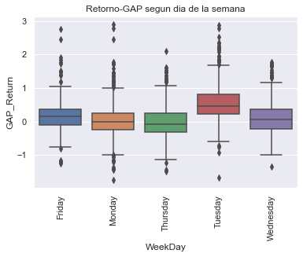

```python
sns.boxplot(data =df_Retorno_Gaps,x='WeekDay',y='GAP_Return')
plt.xticks(rotation=90)
plt.title('Retorno-GAP segun dia de la semana')
plt.show()
```

Se calcula el promedio de Retorno Gap por dia de la semana

```python
dia_inversion_gap=df_retorno_gaps.groupby(['WeekDay']).mean()
#dia_inversion.reset_index(inplace=True)
dia_inversion_gap
```

| WeekDay | GAP_Return |
| --- | --- |
| Friday | 0.000155 |
| Monday | 0.000028 |
| Thursday | -0.000007 |
| Tuesday | 0.000502 |
| Wednesday | 0.000097 |

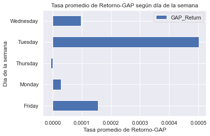

```python
plt.figure(figsize=(10,10))
dia_inversion_gap.plot.barh()
plt.title('Tasa promedio de Retorno-GAP según día de la semana')
plt.xlabel('Tasa promedio de Retorno-GAP')
plt.ylabel('Dia de la semana')
plt.show()
```

# Análisis del mejor día para invertir usando el rendimiento intradiario.

**Intra: Considera la diferencia entre el precio de cierre y el precio de apertura (escala logaritmica).**

Se calcula el Rendimiento intradiario acumulado por día de la semana

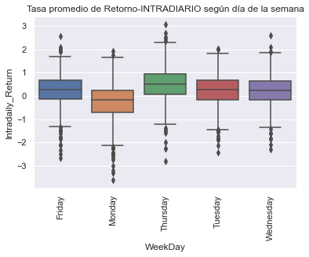

```python
df_Retorno_Intra = df_global[['WeekDay','Ticker','Intradaily_Return']].groupby([df_global['WeekDay'],df_global['Ticker']]).sum()
df_Retorno_Intra.reset_index(inplace=True)
sns.boxplot(data =df_Retorno_Intra,x='WeekDay',y='Intradaily_Return')
plt.xticks(rotation=90)
plt.title('Tasa promedio de Retorno-INTRADIARIO según día de la semana')
plt.show()
```

```python
df_retorno_intra= pd.DataFrame()
df_retorno_intra=df_global[['WeekDay','Intradaily_Return']]
df_retorno_intra
```

|  | WeekDay | Intradaily_Return |
| --- | --- | --- |
| 1579 | Monday | 0.000000 |
| 1580 | Tuesday | 0.000000 |
| 1581 | Wednesday | 0.000000 |
| 1582 | Thursday | 0.000000 |
| 1583 | Friday | 0.000000 |
| ... | ... | ... |
| 1575 | Thursday | -0.005009 |
| 1576 | Monday | -0.014664 |
| 1577 | Tuesday | -0.010234 |
| 1578 | Wednesday | -0.003464 |
| 5283 | Thursday | 0.000000 |

2658355 rows × 2 columns

Se calcula el promedio del Rendimiento Intradiario por dia de la semana

```python
dia_inversion_intra=df_retorno_intra.groupby(['WeekDay']).mean()
dia_inversion_intra
```

| WeekDay | Intradaily_Return |
| --- | --- |
| Friday | 0.000215 |
| Monday | -0.000297 |
| Thursday | 0.000456 |
| Tuesday | 0.000232 |
| Wednesday | 0.000206 |

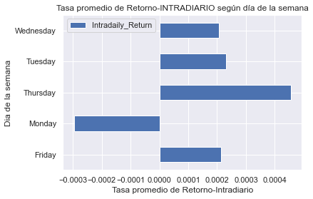

```python
plt.figure(figsize=(10,10))
dia_inversion_intra.plot.barh()
plt.title('Tasa promedio de Retorno-INTRADIARIO según día de la semana')
plt.xlabel('Tasa promedio de Retorno-Intradiario')
plt.ylabel('Dia de la semana')
plt.show()
```

# Mejores industrias que pertenecen al SP500 en las cuales se puede invertir

```python
df_simbolos=df_simbolos.rename({'Symbol': 'Ticker'},axis=1) #Se renombra la columa Symbols para hacer un join con df_global
df_simbolos
```

|  | Ticker | Security | GICS Sector | GICS Sub-Industry |
| --- | --- | --- | --- | --- |
| 0 | MMM | 3M | Industrials | Industrial Conglomerates |
| 1 | AOS | A. O. Smith | Industrials | Building Products |
| 2 | ABT | Abbott | Health Care | Health Care Equipment |
| 3 | ABBV | AbbVie | Health Care | Pharmaceuticals |
| 4 | ABMD | Abiomed | Health Care | Health Care Equipment |
| ... | ... | ... | ... | ... |
| 498 | YUM | Yum! Brands | Consumer Discretionary | Restaurants |
| 499 | ZBRA | Zebra Technologies | Information Technology | Electronic Equipment & Instruments |
| 500 | ZBH | Zimmer Biomet | Health Care | Health Care Equipment |
| 501 | ZION | Zions Bancorporation | Financials | Regional Banks |
| 502 | ZTS | Zoetis | Health Care | Pharmaceuticals |

503 rows × 4 columns

```python
# Se realiza el left join
df_global_ind= df_global.merge(df_simbolos, on='Ticker', how='left')
df_global_ind
```

|  | Date | Open | High | Low | Close | Adj Close | Volume | Ticker | GAP_Return | Intradaily_Return | Variation | Volatility | WeekDay | Year_Month | Year | Security | GICS Sector | GICS Sub-Industry |
| --- | --- | --- | --- | --- | --- | --- | --- | --- | --- | --- | --- | --- | --- | --- | --- | --- | --- | --- |
| 0 | 2000-01-03 | NaN | NaN | NaN | NaN | NaN | NaN | OGN | 0.000000 | 0.000000 | NaN | NaN | Monday | 2000-01 | 2000 | Organon & Co. | Health Care | Pharmaceuticals |
| 1 | 2000-01-04 | NaN | NaN | NaN | NaN | NaN | NaN | OGN | 0.000000 | 0.000000 | NaN | NaN | Tuesday | 2000-01 | 2000 | Organon & Co. | Health Care | Pharmaceuticals |
| 2 | 2000-01-05 | NaN | NaN | NaN | NaN | NaN | NaN | OGN | 0.000000 | 0.000000 | NaN | NaN | Wednesday | 2000-01 | 2000 | Organon & Co. | Health Care | Pharmaceuticals |
| 3 | 2000-01-06 | NaN | NaN | NaN | NaN | NaN | NaN | OGN | 0.000000 | 0.000000 | NaN | NaN | Thursday | 2000-01 | 2000 | Organon & Co. | Health Care | Pharmaceuticals |
| 4 | 2000-01-07 | NaN | NaN | NaN | NaN | NaN | NaN | OGN | 0.000000 | 0.000000 | NaN | NaN | Friday | 2000-01 | 2000 | Organon & Co. | Health Care | Pharmaceuticals |
| ... | ... | ... | ... | ... | ... | ... | ... | ... | ... | ... | ... | ... | ... | ... | ... | ... | ... | ... |
| 2658350 | 2020-12-24 | 138.110001 | 138.649994 | 136.720001 | 137.419998 | 135.851578 | 245300.0 | JBHT | -0.002387 | -0.005009 | -0.007368 | 41.121954 | Thursday | 2020-12 | 2020 | J.B. Hunt | Industrials | Trucking |
| 2658351 | 2020-12-28 | 138.759995 | 139.119995 | 136.429993 | 136.740005 | 135.179367 | 493100.0 | JBHT | 0.009704 | -0.014664 | -0.004948 | 41.126244 | Monday | 2020-12 | 2020 | J.B. Hunt | Industrials | Trucking |
| 2658352 | 2020-12-29 | 137.500000 | 138.270004 | 135.649994 | 136.100006 | 134.546661 | 491100.0 | JBHT | 0.005543 | -0.010234 | -0.004680 | 41.126668 | Tuesday | 2020-12 | 2020 | J.B. Hunt | Industrials | Trucking |
| 2658353 | 2020-12-30 | 135.910004 | 136.779999 | 134.949997 | 135.440002 | 133.894196 | 395000.0 | JBHT | -0.001397 | -0.003464 | -0.004849 | 41.127576 | Wednesday | 2020-12 | 2020 | J.B. Hunt | Industrials | Trucking |
| 2658354 | 2020-12-31 | NaN | NaN | NaN | NaN | NaN | NaN | JBHT | 0.000000 | 0.000000 | 0.000000 | 41.086614 | Thursday | 2020-12 | 2020 | J.B. Hunt | Industrials | Trucking |

2658355 rows × 18 columns

Se analizan las industrias de acuerdo a su retorno gap

```python
df_emp_r_gaps= pd.DataFrame()

df_emp_r_gaps=df_global_ind[['GICS Sector','GAP_Return']]
df_emp_r_gaps
```

|  | GICS Sector | GAP_Return |
| --- | --- | --- |
| 0 | Health Care | 0.000000 |
| 1 | Health Care | 0.000000 |
| 2 | Health Care | 0.000000 |
| 3 | Health Care | 0.000000 |
| 4 | Health Care | 0.000000 |
| ... | ... | ... |
| 2658350 | Industrials | -0.002387 |
| 2658351 | Industrials | 0.009704 |
| 2658352 | Industrials | 0.005543 |
| 2658353 | Industrials | -0.001397 |
| 2658354 | Industrials | 0.000000 |

2658355 rows × 2 columns

Se agrupan por industria y se calcula el promedio de retorno gap de cada una

```python
df_emp_r_gaps =df_emp_r_gaps.groupby(['GICS Sector']).mean()
df_emp_r_gaps = df_emp_r_gaps.sort_values('GAP_Return',ascending=True)
df_emp_r_gaps
```

| GICS Sector | GAP_Return |
| --- | --- |
| Consumer Staples | -0.000083 |
| Utilities | 0.000011 |
| Real Estate | 0.000054 |
| Industrials | 0.000118 |
| Financials | 0.000120 |
| Health Care | 0.000156 |
| Information Technology | 0.000169 |
| Materials | 0.000224 |
| Communication Services | 0.000226 |
| Consumer Discretionary | 0.000337 |
| Energy | 0.000443 |

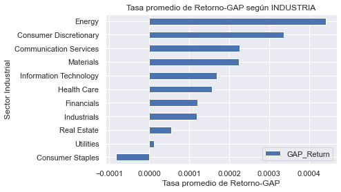

```python
plt.figure(figsize=(10,10))
df_emp_r_gaps.plot.barh()
plt.title('Tasa promedio de Retorno-GAP según INDUSTRIA')
plt.xlabel('Tasa promedio de Retorno-GAP')
plt.ylabel('Sector Industrial')
plt.show()
```

# Los momentos de alta volatilidad que afectaron al SP500

”La volatilidad es una medida de la intensidad de los cambios aleatorios o impredecibles en la rentabilidad o en el precio de un título. En la representación gráfica de una serie histórica de rendimientos se asocia la volatilidad con la amplitud de las fluctuaciones del rendimiento tanto es que se consideren en valor absoluto como en desviaciones alrededor de un valor medio ”

```python
df_volatibilidades=pd.DataFrame
df_volatibilidades= df_global[['Year_Month','Volatility']]
df_volatibilidades = df_volatibilidades.sort_values('Volatility',ascending=False)
df_volatibilidades
```

|  | Year_Month | Volatility |
| --- | --- | --- |
| 4011 | 2009-09 | 214.222165 |
| 4010 | 2009-09 | 213.994093 |
| 4009 | 2009-09 | 213.990581 |
| 4014 | 2009-09 | 213.760665 |
| 4013 | 2009-09 | 213.593345 |
| ... | ... | ... |
| 1824 | 2000-12 | NaN |
| 1825 | 2000-12 | NaN |
| 1826 | 2000-12 | NaN |
| 1827 | 2000-12 | NaN |
| 1828 | 2000-12 | NaN |

2658355 rows × 2 columns

```python
df_volatibilidades_por_periodo=df_volatibilidades.groupby(['Year_Month']).mean()
df_volatibilidades_por_periodo = df_volatibilidades_por_periodo.sort_values('Volatility',ascending=False)
df_volatibilidades_por_periodo
```

| Year_Month | Volatility |
| --- | --- |
| 2009-06 | 70.404259 |
| 2009-07 | 69.984870 |
| 2009-05 | 69.963379 |
| 2009-08 | 69.494805 |
| 2009-04 | 68.581947 |
| ... | ... |
| 2000-07 | NaN |
| 2000-08 | NaN |
| 2000-09 | NaN |
| 2000-10 | NaN |
| 2000-11 | NaN |

252 rows × 1 columns

```python
df_volatilidades_altas_periodos=df_volatibilidades_por_periodo.head(15)
```

```python
df_volatilidades_altas_periodos
```

| Year_Month | Volatility |
| --- | --- |
| 2009-06 | 70.404259 |
| 2009-07 | 69.984870 |
| 2009-05 | 69.963379 |
| 2009-08 | 69.494805 |
| 2009-04 | 68.581947 |
| 2009-09 | 68.386642 |
| 2009-03 | 66.428753 |
| 2009-02 | 64.056832 |
| 2009-10 | 62.767798 |
| 2009-01 | 62.394770 |
| 2008-12 | 60.838542 |
| 2009-11 | 56.339966 |
| 2008-11 | 55.092214 |
| 2001-01 | 53.695068 |
| 2000-12 | 53.292423 |

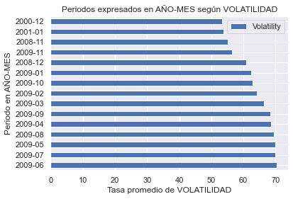

```python
plt.figure(figsize=(10,10))
df_volatilidades_altas_periodos.plot.barh()
plt.title('Periodos expresados en AÑO-MES según VOLATILIDAD')
plt.xlabel('Tasa promedio de VOLATILIDAD')
plt.ylabel('Periodo en AÑO-MES')
plt.show()
```

```python
df_data.columns
tickers=df_data.columns.get_level_values(0)
tickers=tickers.unique()
```

```python
df_volatibilidades_por_anio=pd.DataFrame
df_volatibilidades_por_anio= df_global[['Year','Volatility']]
df_volatibilidades_por_anio = df_volatibilidades_por_anio.sort_values('Volatility',ascending=False)
df_volatibilidades_por_anio
```

|  | Year | Volatility |
| --- | --- | --- |
| 4011 | 2009 | 214.222165 |
| 4010 | 2009 | 213.994093 |
| 4009 | 2009 | 213.990581 |
| 4014 | 2009 | 213.760665 |
| 4013 | 2009 | 213.593345 |
| ... | ... | ... |
| 1824 | 2000 | NaN |
| 1825 | 2000 | NaN |
| 1826 | 2000 | NaN |
| 1827 | 2000 | NaN |
| 1828 | 2000 | NaN |

2658355 rows × 2 columns

```python
df_volatibilidades_por_anio=df_volatibilidades_por_anio.groupby(['Year']).mean()
df_volatibilidades_por_anio = df_volatibilidades_por_anio.sort_values('Year',ascending=True)
df_volatibilidades_por_anio
```

| Year | Volatility |
| --- | --- |
| 2000 | 53.292423 |
| 2001 | 49.204960 |
| 2002 | 42.661270 |
| 2003 | 41.409694 |
| 2004 | 27.699378 |
| 2005 | 25.376964 |
| 2006 | 25.347923 |
| 2007 | 25.469739 |
| 2008 | 39.857979 |
| 2009 | 64.927445 |
| 2010 | 34.073545 |
| 2011 | 28.831589 |
| 2012 | 31.717901 |
| 2013 | 23.582910 |
| 2014 | 21.752125 |
| 2015 | 22.969208 |
| 2016 | 27.730606 |
| 2017 | 22.331045 |
| 2018 | 23.458530 |
| 2019 | 27.107360 |
| 2020 | 44.870614 |

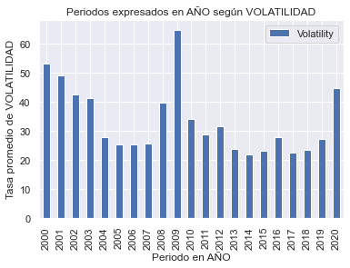

```python
plt.figure(figsize=(20,20))
df_volatibilidades_por_anio.plot.bar()
plt.title('Periodos expresados en AÑO según VOLATILIDAD')
plt.xlabel('Periodo en AÑO')
plt.ylabel('Tasa promedio de VOLATILIDAD')
plt.show()
```

```python
df_volatibilidades_anio=pd.DataFrame
df_volatibilidades_anio= df_global[['Year','Volatility']]
df_volatibilidades_anio = df_volatibilidades_anio.sort_values('Year',ascending=True)
df_volatibilidades_anio
```

|  | Year | Volatility |
| --- | --- | --- |
| 1579 | 2000 | NaN |
| 1708 | 2000 | NaN |
| 1709 | 2000 | NaN |
| 1710 | 2000 | NaN |
| 1711 | 2000 | NaN |
| ... | ... | ... |
| 1520 | 2020 | 58.466436 |
| 1519 | 2020 | 58.455116 |
| 1518 | 2020 | 58.454546 |
| 1544 | 2020 | 69.076115 |
| 5283 | 2020 | 41.086614 |

2658355 rows × 2 columns

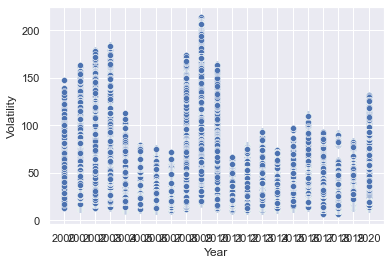

```python
ax = sns.scatterplot(x='Year',y='Volatility', data=df_volatibilidades_anio )
style = dict(size=12, color='black')
```

# Las 9 mejores empresas para invertir

# Comprender el precio de cierre ajustado

Los valores de las acciones se expresan en términos del precio de cierre y el precio de cierre ajustado. El precio de cierre es el precio sin procesar, que es solo el valor en efectivo del último precio negociado antes del cierre del mercado. El precio de cierre ajustado tiene en cuenta cualquier cosa que pueda afectar el precio de las acciones después del cierre del mercado.

```python
list_tickers=[]
df_empresas=pd.DataFrame
for i in tickers:
    df_AdjClose_tickers=df_data.loc[:,i]
    df_AdjClose_tickers.reset_index(inplace=True)
    df_AdjClose_tickers.rename(columns={'Adj Close':i},inplace=True)
    df_AdjClose_tickers.drop(columns={'Open','High','Low','Close','Volume'},inplace=True)
    df_AdjClose_tickers.set_index(['Date'],inplace=True)

    list_tickers.append(df_AdjClose_tickers)
df_empresas=list_tickers[0]
```

[output not shown]

[output cut: 4975 more lines]

[output not shown]

```python
df_empresas
```

| Date | OGN |
| --- | --- |
| 2014-09-24 | NaN |
| 2014-09-25 | NaN |
| 2014-09-26 | NaN |
| 2014-09-29 | NaN |
| 2014-09-30 | NaN |
| ... | ... |
| 2014-09-19 | NaN |
| 2014-09-22 | NaN |
| 2014-09-23 | NaN |
| 2020-12-31 | NaN |
| 2001-09-12 | NaN |

5285 rows × 1 columns

```python
df_global_empresa2=df_empresas
```

# Rendimientos históricos

**¿Qué son los rendimientos históricos?**

Los rendimientos históricos a menudo se asocian con el rendimiento anterior de un valor o índice, como el S&P 500 . Los analistas revisan los datos de rendimiento históricos cuando intentan predecir rendimientos futuros o estimar cómo podría reaccionar un valor ante una situación particular, como una caída en el gasto del consumidor. Los rendimientos históricos también pueden ser útiles al estimar dónde pueden caer los puntos futuros de los datos en términos de desviaciones estándar .>

CONCLUSIONES CLAVE

- Los rendimientos históricos a menudo se asocian con el rendimiento anterior de un valor o índice, como el S&P 500.
- Los inversores estudian los datos históricos de rendimiento cuando intentan pronosticar rendimientos futuros o estimar cómo podría reaccionar un valor en una situación.
- El cálculo del rendimiento histórico se realiza restando el precio más reciente del precio más antiguo y dividiendo el resultado por el precio más antiguo.

Fuente: https://www.investopedia.com/terms/h/historical-returns.asp

```python
i=1
while i<503:
    df_global_empresa2= df_global_empresa2.merge(list_tickers[i], how='left', left_index=True, right_index=True)
    i=i+1
```

```python
df_global_empresa2
```

| Date | OGN | CFG | BA | WY | ROST | JCI | ORCL | EQIX | AZO | NFLX | ... | BK | ETN | ALGN | SO | NSC | MLM | AAL | CLX | INCY | JBHT |
| --- | --- | --- | --- | --- | --- | --- | --- | --- | --- | --- | --- | --- | --- | --- | --- | --- | --- | --- | --- | --- | --- |
| 2014-09-24 | NaN | 18.318607 | 111.806602 | 23.506256 | 35.262127 | 34.208633 | 34.910759 | 167.736191 | 508.630005 | 64.365715 | ... | 32.965572 | 52.896015 | 53.799999 | 30.613419 | 94.141785 | 123.546494 | 34.138130 | 78.263275 | 49.330002 | 67.667778 |
| 2014-09-25 | NaN | 18.294802 | 110.554451 | 23.352814 | 34.847668 | 33.822449 | 34.326248 | 164.678299 | 504.619995 | 63.355713 | ... | 32.486462 | 51.944962 | 52.830002 | 30.528866 | 92.748062 | 122.033119 | 33.278069 | 77.935585 | 48.660000 | 67.760796 |
| 2014-09-26 | NaN | 18.453541 | 111.902252 | 23.615866 | 35.397182 | 34.162292 | 34.494518 | 167.432861 | 508.380005 | 64.107140 | ... | 32.730209 | 52.638107 | 53.189999 | 30.613419 | 94.023529 | 122.126564 | 33.958561 | 78.345184 | 49.700001 | 69.025818 |
| 2014-09-29 | NaN | 18.437664 | 111.971825 | 23.564714 | 35.141045 | 34.216358 | 34.042858 | 169.317047 | 507.839996 | 64.222855 | ... | 32.452843 | 52.138401 | 53.119999 | 30.740238 | 94.116470 | 121.154961 | 33.107944 | 78.861244 | 50.520000 | 68.830444 |
| 2014-09-30 | NaN | 18.588470 | 110.763145 | 23.279749 | 35.196945 | 34.424904 | 33.901161 | 169.644379 | 509.660004 | 64.454285 | ... | 32.553692 | 51.074516 | 51.680000 | 30.754335 | 94.268501 | 120.454353 | 33.533249 | 78.672867 | 49.049999 | 68.876968 |
| ... | ... | ... | ... | ... | ... | ... | ... | ... | ... | ... | ... | ... | ... | ... | ... | ... | ... | ... | ... | ... | ... |
| 2014-09-19 | NaN | NaN | 112.476158 | 23.667007 | 35.159668 | 34.687519 | 35.247284 | 173.636383 | 526.440002 | 65.360001 | ... | 33.352211 | 53.492439 | 54.880001 | 30.782513 | 94.606354 | 119.977875 | 34.620155 | 74.191994 | 49.320000 | 69.221107 |
| 2014-09-22 | NaN | NaN | 111.832680 | 23.287056 | 34.735893 | 34.486683 | 35.052456 | 171.049561 | 505.380005 | 63.254288 | ... | 33.066433 | 52.444668 | 53.939999 | 30.627506 | 93.761688 | 120.146042 | 33.627766 | 79.647667 | 47.410000 | 68.486305 |
| 2014-09-23 | NaN | NaN | 110.763145 | 23.126303 | 34.540302 | 34.254982 | 34.388237 | 167.073532 | 507.790009 | 63.414288 | ... | 32.747009 | 52.501087 | 52.930000 | 30.578192 | 92.967682 | 121.444565 | 33.391479 | 77.698044 | 47.470001 | 67.835197 |
| 2020-12-31 | NaN | NaN | NaN | NaN | NaN | NaN | NaN | NaN | NaN | NaN | ... | NaN | NaN | NaN | NaN | NaN | NaN | NaN | NaN | NaN | NaN |
| 2001-09-12 | NaN | NaN | NaN | NaN | NaN | NaN | NaN | NaN | NaN | NaN | ... | NaN | NaN | NaN | NaN | NaN | NaN | NaN | NaN | NaN | NaN |

5285 rows × 503 columns

PyPortfolioOpt es una biblioteca que implementa métodos de optimización de cartera, incluidas las técnicas clásicas de frontera eficiente y la asignación de Black-Litterman, así como los desarrollos más recientes en el campo, como la contracción y la paridad de riesgo jerárquico, junto con algunas características experimentales novedosas como matrices de covarianza ponderadas exponencialmente.

```python
# Se calcula el rendimiento histórico promedio anualizado
mean_returns=mean_historical_return(df_global_empresa2,frequency=252)
```

```python
mean_returns_ordered=mean_returns.sort_values(ascending=False)
empresas_recomendadas=mean_returns_ordered[:9]
df_empresas_recomendadas= pd.DataFrame(empresas_recomendadas, columns=['Mean Historical Return'])
df_empresas_recomendadas.reset_index(inplace=True)
df_empresas_recomendadas.rename(columns={'index':'Ticker'},inplace=True)
df_empresas_recomendadas
```

|  | Ticker | Mean Historical Return |
| --- | --- | --- |
| 0 | TSLA | 0.427733 |
| 1 | PAYC | 0.392239 |
| 2 | MRNA | 0.380185 |
| 3 | SEDG | 0.344088 |
| 4 | CZR | 0.336412 |
| 5 | CARR | 0.310215 |
| 6 | EPAM | 0.299750 |
| 7 | NOW | 0.295695 |
| 8 | ENPH | 0.294888 |

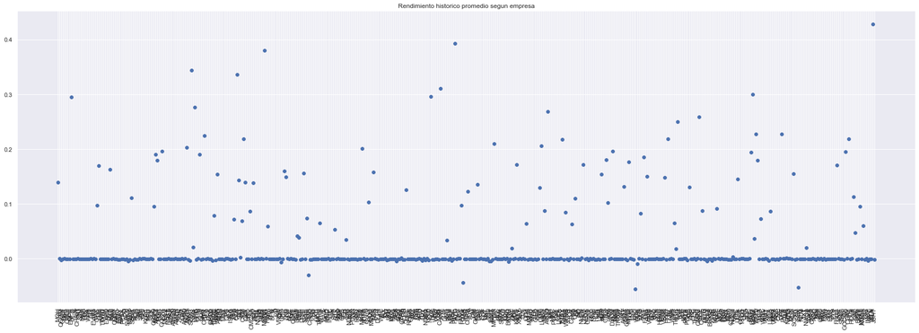

```python
plt.figure(figsize=(30,10))
plt.plot(mean_returns,linestyle='None',marker='o')
plt.xticks(rotation=90)
plt.title('Rendimiento historico promedio segun empresa')
plt.show()
```

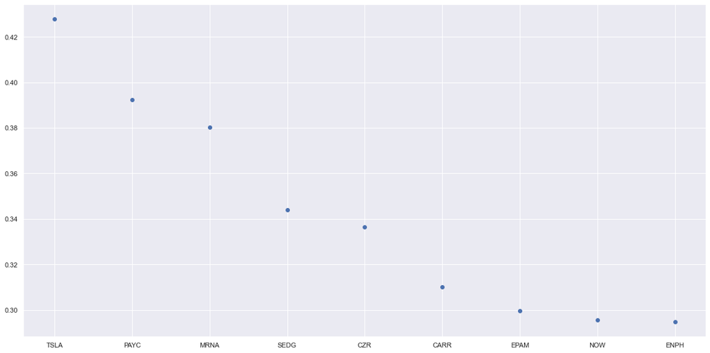

```python
plt.figure(figsize=(20,10))
plt.plot(empresas_recomendadas,linestyle='None',marker='o')
plt.show()
```

```python
lista_recomendadas=empresas_recomendadas.index
lista_recomendadas=lista_recomendadas.tolist()
lista_recomendadas
```

```
['TSLA', 'PAYC', 'MRNA', 'SEDG', 'CZR', 'CARR', 'EPAM', 'NOW', 'ENPH']
```

```python
df_empresas_recomendadas=df_empresas_recomendadas.merge(df_simbolos, on='Ticker', how='left')
df_empresas_recomendadas
```

|  | Ticker | Mean Historical Return | Security | GICS Sector | GICS Sub-Industry |
| --- | --- | --- | --- | --- | --- |
| 0 | TSLA | 0.427733 | Tesla, Inc. | Consumer Discretionary | Automobile Manufacturers |
| 1 | PAYC | 0.392239 | Paycom | Information Technology | Application Software |
| 2 | MRNA | 0.380185 | Moderna | Health Care | Biotechnology |
| 3 | SEDG | 0.344088 | SolarEdge | Information Technology | Semiconductor Equipment |
| 4 | CZR | 0.336412 | Caesars Entertainment | Consumer Discretionary | Casinos & Gaming |
| 5 | CARR | 0.310215 | Carrier Global | Industrials | Building Products |
| 6 | EPAM | 0.299750 | EPAM Systems | Information Technology | IT Consulting & Other Services |
| 7 | NOW | 0.295695 | ServiceNow | Information Technology | Systems Software |
| 8 | ENPH | 0.294888 | Enphase | Information Technology | Electronic Components |

```python
print("Las 9 mejores empresas para invertir segun el promedio de sus rendimientos historicos son: ")
for i in lista_recomendadas:
    print(f'- {i}')
```

[output not shown]